# PQHS 471 HW1

Youjun Li

Feb 06, 2018

## ISLR Chapter 2

### 1

1. Large n small p indicate relative small variance, hence flexible learning should perform better.
2. The opposite of part a, flexible learning tends to overfit.
3. Flexible learning works better to capture non-linear relationship.
4. Similar to part b, flexible learning tends to overfit.

### 3

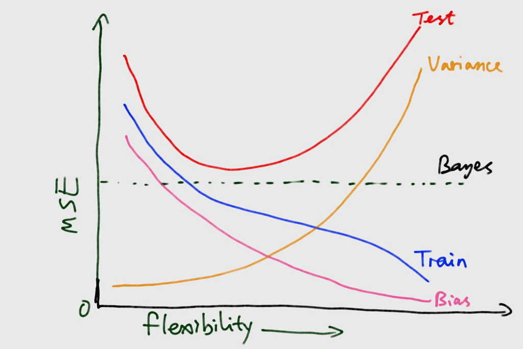

b. More flexible model would loosen the assumptions and fit the training data better and thus reduce training error and bias. But the variance would increase as the model is fitted to match the current training data, meaning a change of training data will result a rapid change of the estimate. Testing error reflects both variance and bias, thus would have a “U” shaped curve. Bayes error is also called irreducible error, which is the same over flexibility.